# Interactions in Linear Models

- Show All Code
- Hide All Code
- View Source

STA 631 – Statistical Modeling I

Author

Andrew DiLernia

## Learning Objectives

- The concept of an interaction term
- How to assess when interactions are useful in models
- How to interpret the effects of interaction terms

## Possum Data

For this activity, we will analyze data collected on possums consisting of measurements on 104 mountain brushtail possums, trapped at seven sites in two different geographic regions of Australia.[^1]

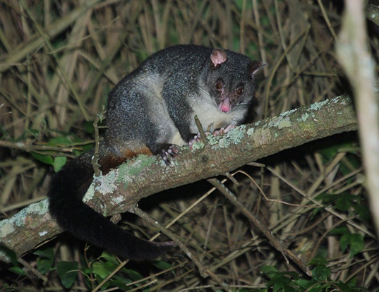

Depiction of a mountain brushtail possum. Image obtained from https://www.worldlifeexpectancy.com/images/a/w/b/trichosurus-cunninghami/trichosurus-cunninghami.jpg

```r
# Importing data from GitHub
possums <- read_csv("https://raw.githubusercontent.com/dilernia/STA631/main/data/possum.csv")

# Display 5 random rows from data set
possums |>
  dplyr::sample_n(size = 5) |>
  dplyr::select(region, sex, total_length_cm, ear_conch_length_mm, total_length_cm, foot_length_mm) |>
  gt()
```

Table 1: Several rows and columns from the possums data set.

| region | sex | total_length_cm | ear_conch_length_mm | foot_length_mm |
| --- | --- | --- | --- | --- |
| New South Wales / Queensland | Female | 87.5 | 43.5 | 66.7 |
| Victoria | Male | 84.0 | 53.5 | 75.0 |
| Victoria | Female | 89.5 | 51.3 | 77.2 |
| Victoria | Male | 90.0 | 56.2 | 73.6 |
| New South Wales / Queensland | Male | 81.5 | 46.8 | 66.0 |

We first note that there are differences in possum foot lengths (mm) by sex and by geographic region.

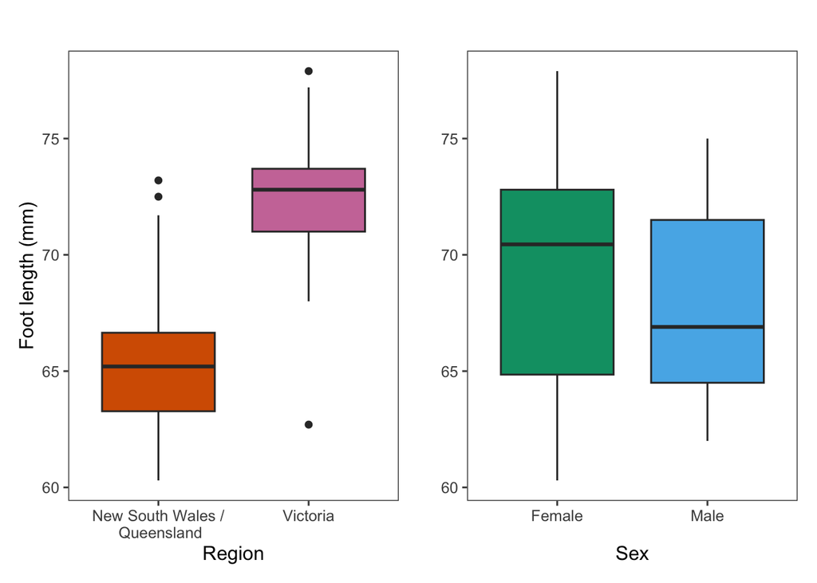

```r
# Creating side-by-side box plots for foot length by region
region_boxes <- possums |>
  ggplot(aes(x = region, y = foot_length_mm, fill = region)) +
  labs(y = "Foot length (mm)", x = "Geographic region", title = "") +
  geom_boxplot() + scale_fill_manual(values = my_colors_full[c(6, 1)]) +
  scale_x_discrete("Region", labels = c("New South Wales /\n Queensland", "Victoria")) +
  theme(legend.position = "none")

# Creating side-by-side box plots for foot length by sex
sex_boxes <- possums |>
  ggplot(aes(x = sex, y = foot_length_mm, fill = sex)) +
  labs(y = "", x = "Sex", title = "") +
  geom_boxplot() + scale_fill_manual(values = my_colors_full[2:3]) +
  theme(legend.position = "none")

region_boxes | sex_boxes
```

Let’s model the foot lengths (mm) using the region and sex of the possum. The corresponding MLR model is:

$$Y = \beta_0 + x_1\beta_1 + x_2\beta_2 + \varepsilon,$$

where $Y$ is a possum’s foot length (mm), $x_1$ is an indicator of the region being Victoria ($x_1 = 1$) or New South Wales / Queensland ($x_1 = 0$), and $x_2$ is an indicator of the sex being male ($x_2 = 1$) or female ($x_2 = 0$), and $\varepsilon$ the independent and normally distributed error term.

```r
# Modeling foot length using region and sex
fit_2 <- lm(foot_length_mm ~ region + sex,
           data = possums)
```

```r
# Display model output
fit_2 |>
  tbl_regression(intercept = TRUE) |>
  add_vif() |>
  add_glance_source_note()
```

Table 2: Two-predictor MLR model output (region and sex)

| **Characteristic** | **Beta** | **95% CI** | **p-value** | **VIF** |
| --- | --- | --- | --- | --- |
| (Intercept) | 65 | 64, 66 | <0.001 |  |
| region |  |  |  | 1.0 |
| New South Wales / Queensland | — | — |  |  |
| Victoria | 7.0 | 5.9, 8.1 | <0.001 |  |
| sex |  |  |  | 1.0 |
| Female | — | — |  |  |
| Male | 0.21 | -0.88, 1.3 | 0.7 |  |

Abbreviations: CI = Confidence Interval, VIF = Variance Inflation Factor  
R² = 0.630; Adjusted R² = 0.622; Sigma = 2.70; Statistic = 85.0; p-value = <0.001; df = 2; Log-likelihood = -247; AIC = 502; BIC = 513; Deviance = 730; Residual df = 100; No. Obs. = 103

Here, our estimated MLR model is:

$$\hat{y} = 65 + 7.0 x_1 + 0.21 x_2,$$

where $\hat{y}$ is the estimated possum foot length (mm), $x_1$ is an indicator of the region being Victoria ($x_1 = 1$) or New South Wales / Queensland ($x_1 = 0$), and $x_2$ is an indicator of the sex being male ($x_2 = 1$) or female ($x_2 = 0$).

**Tip**

1. How do we interpret the estimated slopes?
2. How do we interpret the estimated intercept?
3. Using the model output, confirm that the predicted foot length (mm) of a female possum from the Victoria region based on this two-predictor model is roughly 72.

## Interaction of Two Categorical Predictors

The two predictor model above assumes that the variation in the foot lengths of the possums varies by the sex of the possum independent of its geographic region. Is this a reasonable assumption? In other words, is the relationship between the sex of the possum and its foot length consistent across the regions?

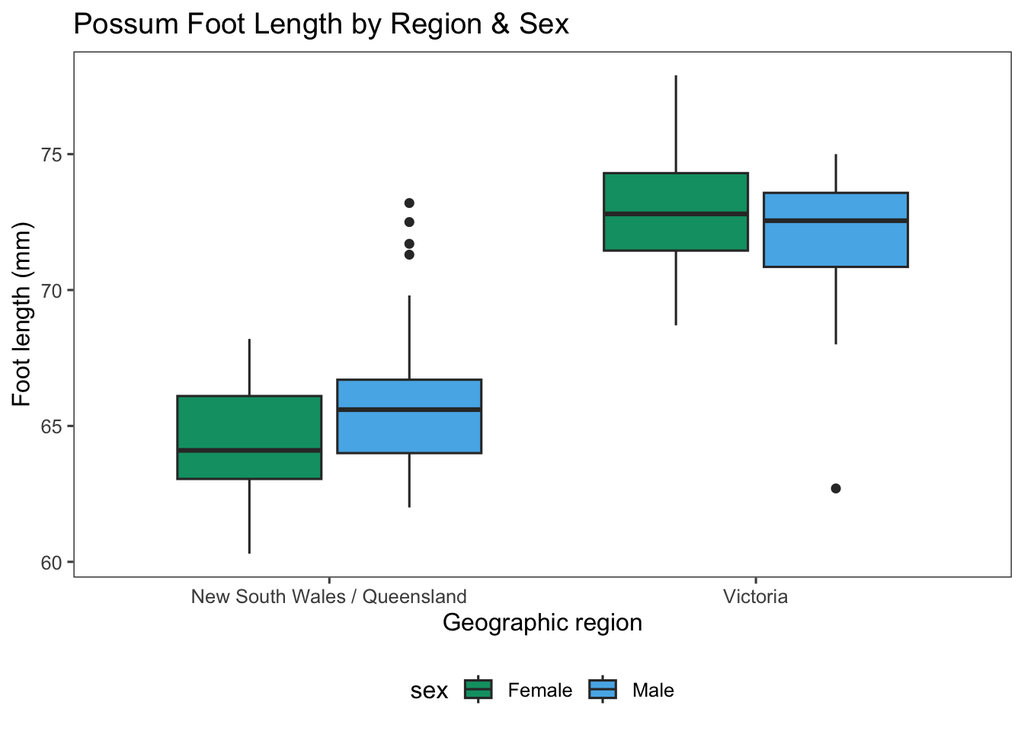

It appears that the relationship between the sex of the possum and its foot length may depend on its geographic region. To incorporate this into our analysis, we can use an *interaction term* in our model. The full interaction model is

$$Y = \beta_0 + x_1\beta_1 + x_2\beta_2 + (x_1 \cdot x_2)\beta_3 + \varepsilon$$

where $Y$ is a possum’s foot length (mm), $x_1$ is an indicator of the region being Victoria ($x_1 = 1$) or New South Wales / Queensland ($x_1 = 0$), $x_2$ is an indicator of the sex being male ($x_2 = 1$) or female ($x_2 = 0$), and $\varepsilon$ is the independent and normally distributed error term.

```r
# Modeling foot length using population and sex with interaction
fit_int <- lm(foot_length_mm ~ region*sex,
             data = possums)
```

```r
# Display model output
fit_int |>
  tbl_regression(intercept = TRUE) |>
  add_vif() |>
  add_glance_source_note()
```

Table 3: Interaction MLR model output (region and sex)

| **Characteristic** | **Beta** | **95% CI** | **p-value** | **VIF** |
| --- | --- | --- | --- | --- |
| (Intercept) | 64 | 63, 66 | <0.001 |  |
| region |  |  |  | 2.4 |
| New South Wales / Queensland | — | — |  |  |
| Victoria | 8.6 | 7.0, 10 | <0.001 |  |
| sex |  |  |  | 1.9 |
| Female | — | — |  |  |
| Male | 1.5 | 0.07, 3.0 | 0.041 |  |
| region * sex |  |  |  | 2.9 |
| Victoria * Male | -2.8 | -4.9, -0.67 | 0.011 |  |

Abbreviations: CI = Confidence Interval, VIF = Variance Inflation Factor  
R² = 0.653; Adjusted R² = 0.643; Sigma = 2.63; Statistic = 62.2; p-value = <0.001; df = 3; Log-likelihood = -244; AIC = 497; BIC = 510; Deviance = 683; Residual df = 99; No. Obs. = 103

Here, our estimated MLR model is:

$$\hat{y} = 64 + 8.6 x_1 + 1.5 x_2 -2.8 (x_1 \cdot x_2),$$

where $\hat{y}$ is the estimated possum foot length (mm), $x_1$ is an indicator of the region being Victoria ($x_1 = 1$) or New South Wales / Queensland ($x_1 = 0$), and $x_2$ is an indicator of the sex being male ($x_2 = 1$) or female ($x_2 = 0$).

**Tip**

1. Is the interaction term important to include in the model?
2. How do we interpret the estimated slopes? In other words, how does the effect of sex on the foot lengths vary for this model?
3. How do we interpret the estimated intercept?
4. Using the model output, confirm that the predicted foot length (mm) of a female possum from the Victoria region based on the interaction model is roughly 73.

## Interaction of Categorical and Quantitative Predictors

We can also include interactions between categorical and quantitative predictors in a model. First, let’s fit a two-predictor model for foot length (mm) using the ear conch length of the possum (mm) and the sex of the possum.

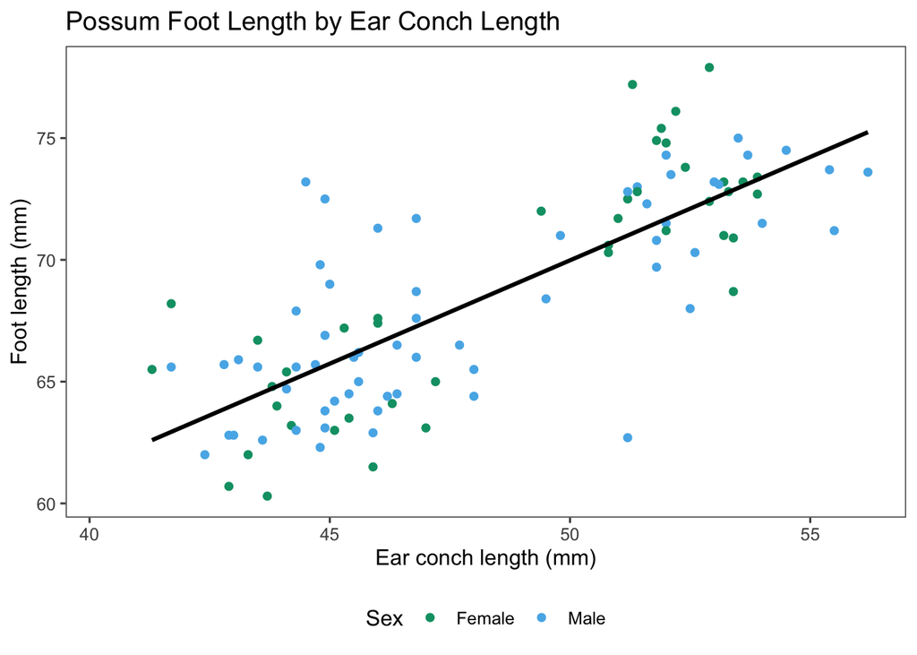

```r
# Creating scatter plot of foot length by ear conch length
possums |>
  ggplot(aes(x = ear_conch_length_mm, y = foot_length_mm, color = sex)) +
  labs(y = "Foot length (mm)", x = "Ear conch length (mm)", color = "Sex", title = "Possum Foot Length by Ear Conch Length") +
  geom_point(aes(x = ear_conch_length_mm, y = foot_length_mm, color = sex)) +
  scale_color_manual(values = my_colors_full[2:3]) +
  geom_smooth(aes(x = ear_conch_length_mm, y = foot_length_mm), color = "black", method = "lm", se = FALSE) +
  theme(legend.position = "bottom")
```

```r
# Modeling foot length using sex and ear conch length
fit_2_qc <- lm(foot_length_mm ~ sex + ear_conch_length_mm, data = possums)
```

```r
# Display model output
fit_2_qc |>
  tbl_regression(intercept = TRUE) |>
  add_vif() |>
  add_glance_source_note()
```

Table 4: Two-predictor MLR model output (sex and ear conch length)

| **Characteristic** | **Beta** | **95% CI** | **p-value** | **VIF** |
| --- | --- | --- | --- | --- |
| (Intercept) | 28 | 21, 35 | <0.001 |  |
| sex |  |  |  | 1.0 |
| Female | — | — |  |  |
| Male | -0.29 | -1.4, 0.81 | 0.6 |  |
| ear_conch_length_mm | 0.84 | 0.71, 0.98 | <0.001 | 1.0 |

Abbreviations: CI = Confidence Interval, VIF = Variance Inflation Factor  
R² = 0.614; Adjusted R² = 0.607; Sigma = 2.76; Statistic = 79.6; p-value = <0.001; df = 2; Log-likelihood = -249; AIC = 506; BIC = 517; Deviance = 760; Residual df = 100; No. Obs. = 103

Here, our estimated MLR model is:

$$\hat{y} = 28 -0.29 x_1 + 0.84 x_2,$$

where $\hat{y}$ is the estimated possum foot length (mm), $x_1$ is an indicator of the sex being male ($x_1 = 1$) or female ($x_1 = 0$), and $x_2$ is the possum’s ear conch length in mm.

**Tip**

1. How can we describe the effect of ear conch length on foot length?
2. How do we interpret the estimated intercept?
3. Using the model output, confirm that the predicted foot length (mm) of a male possum with an ear conch length of 50mm is roughly 70.

The two predictor model above assumes that the relationship between the ear conch length and the foot lengths of the possums is independent of its sex. Does this assumption appear to be true?

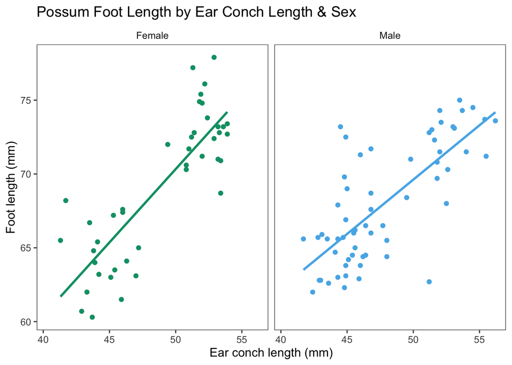

```r
# Created scatter plot faceted by sex of the possum
possums |>
    ggplot(aes(x = ear_conch_length_mm, y = foot_length_mm, color = sex)) +
    labs(y = "Foot length (mm)", x = "Ear conch length (mm)", title = "Possum Foot Length by Ear Conch Length & Sex") +
    geom_point(aes(x = ear_conch_length_mm, y = foot_length_mm, color = sex)) +
    scale_color_manual(values = my_colors_full[2:3]) +
  facet_grid(. ~ sex) +
    geom_smooth(method = "lm", se = FALSE) +
    theme(legend.position = "none")
```

```r
# Modeling foot length using sex, ear conch length, and their interaction
fit_int_qc <- lm(foot_length_mm ~ sex*ear_conch_length_mm, data = possums)
```

```r
# Display model output
fit_int_qc |>
  tbl_regression(intercept = TRUE) |>
  add_vif() |>
  add_glance_source_note()
```

Table 5: Interaction MLR model output (sex and ear conch length)

| **Characteristic** | **Beta** | **95% CI** | **p-value** | **VIF** |
| --- | --- | --- | --- | --- |
| (Intercept) | 21 | 11, 31 | <0.001 |  |
| sex |  |  |  | 145 |
| Female | — | — |  |  |
| Male | 12 | -0.94, 25 | 0.069 |  |
| ear_conch_length_mm | 0.99 | 0.79, 1.2 | <0.001 | 2.4 |
| sex * ear_conch_length_mm |  |  |  | 143 |
| Male * ear_conch_length_mm | -0.26 | -0.53, 0.01 | 0.061 |  |

Abbreviations: CI = Confidence Interval, VIF = Variance Inflation Factor  
R² = 0.628; Adjusted R² = 0.616; Sigma = 2.72; Statistic = 55.6; p-value = <0.001; df = 3; Log-likelihood = -247; AIC = 505; BIC = 518; Deviance = 734; Residual df = 99; No. Obs. = 103

It appears that the relationship between the ear conch length of the possum and its foot length may depend on its sex. To incorporate this into our analysis, we can again use an *interaction term* in our model. The full interaction model is

$$\hat{y} = 21 + 12 x_1 + 0.99 x_2 -0.26 (x_1 \cdot x_2),$$

where $\hat{y}$ is the estimated possum foot length (mm), $x_1$ is an indicator of the sex being male ($x_1 = 1$) or female ($x_1 = 0$), and $x_2$ is the possum’s ear conch length in mm.

**Tip**

1. Is the interaction term important to include in the model?
2. Is the slope for ear conch always the same? How does it vary for this model?
3. Confirm that the predicted foot length (mm) of a male possum with an ear conch length of 50mm is between 69 and 70.

Note the separation of points into two groups in each scatter plot. As shown below, this is due to the region the possums are from.

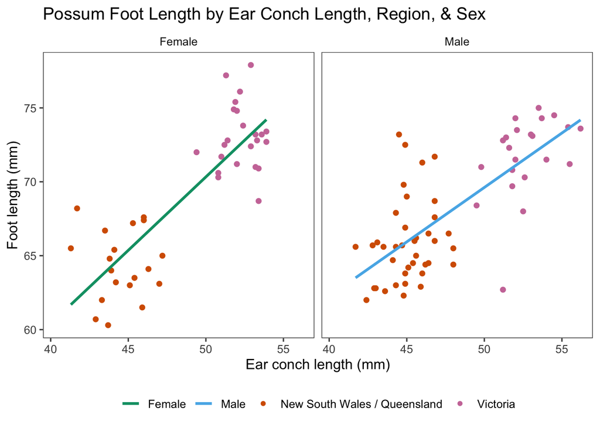

```r
# Create faceted scatter plot coloring points by region
possums |>
    ggplot(aes(x = ear_conch_length_mm, y = foot_length_mm, color = sex)) +
    labs(y = "Foot length (mm)", x = "Ear conch length (mm)", title = "Possum Foot Length by Ear Conch Length, Region, & Sex") +
    geom_point(aes(x = ear_conch_length_mm, y = foot_length_mm, color = region)) +
    facet_grid(. ~ sex) +
    geom_smooth(aes(x = ear_conch_length_mm, y = foot_length_mm, color = sex),
                method = "lm", se = FALSE) +
    scale_color_manual(name = NULL,
                       values = c(my_colors_full[2:3], my_colors_full[c(6, 1)]),
                       breaks = c("Female", "Male", "New South Wales / Queensland", "Victoria"),
                       guide = guide_legend(override.aes = list(linetype = c(1, 1, 0, 0),
                                                                shape = c(NA, NA, 16, 16),
                                                                color = c(my_colors_full[2:3], my_colors_full[c(6, 1)])) ) ) +
    theme(legend.position = "bottom")
```

```r
# Modeling foot length using region, sex, ear conch length, and the interaction between ear conch and sex
fit_int_qc_3 <- lm(foot_length_mm ~ region + ear_conch_length_mm*sex, data = possums)
```

```r
# Display model output
fit_int_qc_3 |>
  tbl_regression(intercept = TRUE) |>
  add_vif() |>
  add_glance_source_note()
```

Table 6: Three-predictor MLR model output with interaction

| **Characteristic** | **Beta** | **95% CI** | **p-value** | **VIF** |
| --- | --- | --- | --- | --- |
| (Intercept) | 42 | 24, 59 | <0.001 |  |
| region |  |  |  | 7.4 |
| New South Wales / Queensland | — | — |  |  |
| Victoria | 4.1 | 1.3, 6.9 | 0.004 |  |
| ear_conch_length_mm | 0.52 | 0.14, 0.90 | 0.008 | 8.9 |
| sex |  |  |  | 145 |
| Female | — | — |  |  |
| Male | 12 | -0.89, 24 | 0.068 |  |
| ear_conch_length_mm * sex |  |  |  | 144 |
| ear_conch_length_mm * Male | -0.24 | -0.50, 0.02 | 0.068 |  |

Abbreviations: CI = Confidence Interval, VIF = Variance Inflation Factor  
R² = 0.657; Adjusted R² = 0.643; Sigma = 2.62; Statistic = 47.0; p-value = <0.001; df = 4; Log-likelihood = -243; AIC = 498; BIC = 514; Deviance = 675; Residual df = 98; No. Obs. = 103

Also including the effect of region, the full interaction model is

$$\hat{y} = 42 + 4.1 x_1 + 0.52 x_2 + 12 x_3 -0.24 (x_2 \cdot x_3),$$

where $\hat{y}$ is the estimated possum foot length (mm), $x_1$ is an indicator of the region being Victoria ($x_1 = 1$) or New South Wales / Queensland ($x_1 = 0$), $x_2$ is the possum’s ear conch length in mm, and $x_3$ is an indicator of the sex being male ($x_3 = 1$) or female ($x_3 = 0$).

**Tip**

Is the slope for ear conch always the same? How does it vary for this model?

## Interaction of Two Quantitative Predictors

```r
# Interpolating to plot contours
possums |>
  dplyr::select(ear_conch_length_mm, total_length_cm,
                foot_length_mm) |>
plot_3d(plot_type = "interactive")
```

[interactive chart not shown]

```r
# Modeling foot length using total length and ear conch length
fit_2_q <- lm(foot_length_mm ~ ear_conch_length_mm + total_length_cm, data = possums)
```

```r
# Display model output
fit_2_q |>
  tbl_regression(intercept = TRUE) |>
  add_vif() |>
  add_glance_source_note()
```

Table 7: Two-predictor MLR model output (ear conch length and total length)

| **Characteristic** | **Beta** | **95% CI** | **p-value** | **VIF** |
| --- | --- | --- | --- | --- |
| (Intercept) | -0.32 | -10, 9.8 | >0.9 |  |
| ear_conch_length_mm | 0.80 | 0.68, 0.91 | <0.001 | 1.0 |
| total_length_cm | 0.35 | 0.24, 0.46 | <0.001 | 1.0 |

Abbreviations: CI = Confidence Interval, VIF = Variance Inflation Factor  
R² = 0.728; Adjusted R² = 0.722; Sigma = 2.32; Statistic = 134; p-value = <0.001; df = 2; Log-likelihood = -231; AIC = 470; BIC = 481; Deviance = 536; Residual df = 100; No. Obs. = 103

Both predictors, total length and ear conch length, have a positive relationship with the response variable, foot length. Does there appear to be an interaction between the two predictors?

```r
# Modeling foot length using total length, ear conch length, and their interaction
fit_int_2_q <- lm(foot_length_mm ~ ear_conch_length_mm *total_length_cm, data = possums)
```

```r
# Display model output
fit_int_2_q |>
  tbl_regression(intercept = TRUE) |>
  add_vif() |>
  add_glance_source_note()
```

Table 8: Interaction MLR model output (ear conch length and total length)

| **Characteristic** | **Beta** | **95% CI** | **p-value** | **VIF** |
| --- | --- | --- | --- | --- |
| (Intercept) | -71 | -185, 43 | 0.2 |  |
| ear_conch_length_mm | 2.2 | -0.08, 4.6 | 0.058 | 433 |
| total_length_cm | 1.2 | -0.15, 2.5 | 0.081 | 155 |
| ear_conch_length_mm * total_length_cm | -0.02 | -0.04, 0.01 | 0.2 | 659 |

Abbreviations: CI = Confidence Interval, VIF = Variance Inflation Factor  
R² = 0.732; Adjusted R² = 0.724; Sigma = 2.31; Statistic = 90.1; p-value = <0.001; df = 3; Log-likelihood = -230; AIC = 471; BIC = 484; Deviance = 528; Residual df = 99; No. Obs. = 103

Using the two quantitative predictors, the full interaction model is

$$\hat{y} = -71 + 2.2 x_1 + 1.2 x_2 -0.02 (x_1 \cdot x_2),$$

where $\hat{y}$ is the estimated possum foot length (mm), $x_1$ is the possum’s ear conch length in mm, and $x_2$ is the possum’s total length in cm.

**Tip**

1. Is the interaction term important to include in the model?
2. Assuming that we retain the interaction term in the model, what does this mean for the effects of total length and ear conch length on the foot lengths of possums?